# Mitonner des beaux petits graphiques à partir des données textuelles du site Marmiton

# Packages

Voici les packages dont j’aurai besoin pour ce projet

```r
knitr::opts_chunk$set(echo = TRUE, warning=FALSE, message=FALSE, cache=TRUE)
library(tidyverse)
library(purrr)
library(rvest)
library(tidytext)
library(proustr)
library(wordcloud)
library(widyr)
library(igraph)
library(ggraph)
```

# Web scraping et mise en forme des données

## Récupérer les urls des listes de recettes de desserts

Si je fais une recherche sur Marmiton pour trouver les fiches-recettes des dessert, il me renvoie une liste de plusieurs pages dont les urls sont de la forme:

- “http://www.marmiton.org/recettes/recherche.aspx?aqt=dessert&dt=dessert&pht=1”
- “http://www.marmiton.org/recettes/recherche.aspx?aqt=dessert&dt=dessert&pht=1&start=12”
- “http://www.marmiton.org/recettes/recherche.aspx?aqt=dessert&dt=dessert&pht=1&start=24”
- “http://www.marmiton.org/recettes/recherche.aspx?aqt=dessert&dt=dessert&pht=1&start=36” etc.

Je vais donc commencer par créer un vecteur `pages` qui liste l’ensemble des pages, qui elles-mêmes listent les recettes de dessert:

```r
pages <- str_c("http://www.marmiton.org/recettes/recherche.aspx?aqt=dessert&dt=dessert&pht=1",
               c("",str_c("&start=",seq(12,9000,by=12))))
pages[1:4]
```

```
## [1] "http://www.marmiton.org/recettes/recherche.aspx?aqt=dessert&dt=dessert&pht=1"
## [2] "http://www.marmiton.org/recettes/recherche.aspx?aqt=dessert&dt=dessert&pht=1&start=12"
## [3] "http://www.marmiton.org/recettes/recherche.aspx?aqt=dessert&dt=dessert&pht=1&start=24"
## [4] "http://www.marmiton.org/recettes/recherche.aspx?aqt=dessert&dt=dessert&pht=1&start=36"
```

## Récupérer les urls des recettes de desserts

Pour ce tuto, je vais me contenter de 1000 recettes (parmi environ 9000) tirées au hasard…

Le résultat est enregistré dans le fichier “data/recettes_sample.csv”.

```r
if(!file.exists("data/recettes_sample.csv")){
  recettes <- pages%>%
    map(.f=recup_recettes) %>%
    bind_rows()
  set.seed(33)
  recettes_sample <- sample_n(recettes, 1000)
  write_csv(recettes_sample,"data/recettes_sample.csv")
}
recettes_sample <- read_csv("data/recettes_sample.csv")
head(recettes_sample)
```

```
## # A tibble: 6 x 1
##   urls
##   <chr>
## 1 http://www.marmiton.org/recettes/recette_verrines-aux-fraises-mascarpon~
## 2 http://www.marmiton.org/recettes/recette_gateau-aux-fraises-et-frambois~
## 3 http://www.marmiton.org/recettes/recette_verrine-de-mousse-de-fruits-ro~
## 4 http://www.marmiton.org/recettes/recette_gateau-a-la-creme-de-marrons_2~
## 5 http://www.marmiton.org/recettes/recette_sables-a-la-confiture-de-framb~
## 6 http://www.marmiton.org/recettes/recette_mini-clafoutis-aux-mures_28342~
```

## Récupérer la liste des ingrédients

On définit maintenant la fonction `recup_ingredients()` qui permet, à partir de l’url d’une recette, de récupérer un tableau qui liste les ingrédients.

```r
recup_ingredients <- function(url){
    html<-read_html(url)
    # Recupere titre
    recette <- html %>%
      html_nodes(".main-title") %>%
      html_text()
    # Recupere quantites
    quantites <- html %>%
      html_nodes(".recipe-ingredient-qt")  %>%
      html_text()
    # Recupere ingredients
    ingredients <- html %>%
      html_nodes(".ingredient") %>%
      html_text()
    # Rassemble le tout dans une tibble
    tib <- bind_cols(url=rep(url,length(ingredients)),
                   recette=rep(recette, length(ingredients)),
                   quantites=quantites,
                   ingredients=ingredients)
    return(tib)
}

recup_ingredients(recettes_sample$urls[24]) %>%
  select(-url)
```

```
## # A tibble: 8 x 3
##   recette                                            quantites ingredients
##   <chr>                                              <chr>     <chr>
## 1 Muffins maxi moelleux aux Framboises des Cantoches 250       " g de far~
## 2 Muffins maxi moelleux aux Framboises des Cantoches 3         " oeuf"
## 3 Muffins maxi moelleux aux Framboises des Cantoches 125       " g de beu~
## 4 Muffins maxi moelleux aux Framboises des Cantoches 150       " ml de la~
## 5 Muffins maxi moelleux aux Framboises des Cantoches 100       " g de suc~
## 6 Muffins maxi moelleux aux Framboises des Cantoches 1         " sachet d~
## 7 Muffins maxi moelleux aux Framboises des Cantoches 1         " pincée d~
## 8 Muffins maxi moelleux aux Framboises des Cantoches 25        " g de cho~
```

On applique alors itérativement la fonction `recup_ingredients()` à l’ensemble des recettes listées dans `recettes_sample`.

Le résultat est enregistré dans le fichier “data/tib_ingredients.csv”.

```r
if(!file.exists("data/tib_ingredients.csv")){
  tib_ingredients <- map(recettes_sample$urls,
                      .f=recup_ingredients) %>%
    bind_rows()
  write_csv(tib_ingredients,"data/tib_ingredients.csv")
}
tib_ingredients <- read_csv("data/tib_ingredients.csv")

select(tib_ingredients,-url) %>%
  head(n=15)
```

```
## # A tibble: 15 x 3
##    recette                                           quantites ingredients
##    <chr>                                             <chr>     <chr>
##  1 verrines aux fraises mascarpone et crème anglaise 125       g de biscu~
##  2 verrines aux fraises mascarpone et crème anglaise 400       g de fraise
##  3 verrines aux fraises mascarpone et crème anglaise 250       g de masca~
##  4 verrines aux fraises mascarpone et crème anglaise 100       g de sucre~
##  5 verrines aux fraises mascarpone et crème anglaise 20        cl de crèm~
##  6 verrines aux fraises mascarpone et crème anglaise 25        cl de crèm~
##  7 verrines aux fraises mascarpone et crème anglaise 6         cuillère à~
##  8 Gâteau aux fraises et framboises                  4         oeuf
##  9 Gâteau aux fraises et framboises                  120       g de sucre
## 10 Gâteau aux fraises et framboises                  120       g de farine
## 11 Gâteau aux fraises et framboises                  50        cl de lait
## 12 Gâteau aux fraises et framboises                  1         gousse de ~
## 13 Gâteau aux fraises et framboises                  4         oeuf
## 14 Gâteau aux fraises et framboises                  100       g de sucre
## 15 Gâteau aux fraises et framboises                  50        g de farine
```

## Nettoyer les ingrédients

Je nettoie la table `tib_ingredients` de manière à isoler les unités de mesure de l’ingrédient lui-même…

```r
tib_ingredients=tib_ingredients %>%
  mutate(ingredients=str_replace(ingredients,"cuillère à soupe","CàS")) %>%
  mutate(ingredients=str_replace(ingredients,"cuillère à café","CàC"))

decompo=str_match(tib_ingredients$ingredients,
                  "(\\w?g|\\w?l|cuillère|CàS|CàC|pot|verre|boîte|pincée|flacon|sachet|feuille|goutte) (de\\s|d\\')(.*)")
tib_ingredients=bind_cols(tib_ingredients,
                          unite=decompo[,2]) %>%
  mutate(ingredients=case_when(!is.na(decompo[,4])~decompo[,4],
                               is.na(decompo[,4])~ingredients))

tib_ingredients %>%
  select(-url) %>%
  head()
```

```
## # A tibble: 6 x 4
##   recette                                    quantites ingredients   unite
##   <chr>                                      <chr>     <chr>         <chr>
## 1 verrines aux fraises mascarpone et crème ~ 125       biscuit sablé g
## 2 verrines aux fraises mascarpone et crème ~ 400       fraise        g
## 3 verrines aux fraises mascarpone et crème ~ 250       mascarpone    g
## 4 verrines aux fraises mascarpone et crème ~ 100       sucre glace   g
## 5 verrines aux fraises mascarpone et crème ~ 20        crème liquide cl
## 6 verrines aux fraises mascarpone et crème ~ 25        crème anglai~ cl
```

## Récupérer la liste des commentaires

On définit maintenant la fonction `recup_commentaires()` qui permet, à partir de l’url d’une recette, de récupérer un tableau qui liste les commentaires (s’il y en a).

```r
recup_commentaires <- function(url){
  url <- str_replace(url,"recettes/recette_","recettes/recette-avis_")
  html <- url %>%
    read_html()
  comments <- html %>% html_nodes(".commentaire")
  if(length(comments)!=0){
      auteur=comments %>% html_nodes("strong") %>%
        html_text() %>%
        unlist()
      date <- comments %>% html_nodes(".infoCom") %>%
        html_text() %>%
        str_extract("\\d{2}/\\d{2}/\\d{2}") %>%
        unlist()
      note <- comments %>% html_nodes(".bulle") %>%
        html_text()%>%
        str_replace("/5","") %>%
        unlist()
      texte <- comments %>%
        html_nodes(".txtCommentaire") %>%
        html_text() %>%
        unlist()
      tib=bind_cols(texte=texte,
                    auteur=auteur,
                    date=date,
                    note=note)
      recette=html %>%
        html_nodes(".fn") %>%
        html_text()
      tib=bind_cols(url=rep(url,nrow(tib)),
                    recette=rep(recette,nrow(tib)),
                    tib)
  }else{tib=NULL}
  return(tib)
}
```

On applique alors itérativement la fonction `recup_commentaires()` à l’ensemble des recettes listées dans `recettes_sample`.

```r
tib_commentaires <- map(recettes_sample$urls,recup_commentaires) %>%
    bind_rows()

select(tib_commentaires,-url) %>%
  head(n=15)
```

```
## # A tibble: 15 x 5
##    recette    texte                                     auteur date  note
##    <chr>      <chr>                                     <chr>  <chr> <chr>
##  1 Verrines ~ "\r\n                            Angeliq~ Angel~ 20/0~ 5
##  2 Verrines ~ "\r\n                            jennyca~ jenny~ 01/0~ 5
##  3 Verrines ~ "\r\n                            Sophie_~ Sophi~ 23/0~ 5
##  4 Verrines ~ "\r\n                            marie_6~ marie~ 30/0~ 5
##  5 Verrines ~ "\r\n                            mappie\~ mappie 12/0~ 2
##  6 Verrines ~ "\r\n                            celine_~ celin~ 06/0~ 5
##  7 Verrine d~ "\r\n                            loic094~ loic0~ 17/1~ 4
##  8 Verrine d~ "\r\n                            jennyja~ jenny~ 25/0~ 5
##  9 Verrine d~ "\r\n                            Korado\~ Korado 15/1~ 5
## 10 Verrine d~ "\r\n                            marmito~ marmi~ 06/0~ 1
## 11 Verrine d~ "\r\n                            cecile9~ cecil~ 14/0~ 1
## 12 Verrine d~ "\r\n                            kocklic~ kockl~ 27/1~ 1
## 13 Verrine d~ "\r\n                            seve02\~ seve02 21/1~ 2
## 14 Verrine d~ "\r\n                            CookIsa~ CookI~ 24/0~ 4
## 15 Verrine d~ "\r\n                            sylvian~ sylvi~ 25/1~ 5
```

## Nettoyer la table des commentaires

Je nettoie la table `tib_commentaires`. Je vais notamment m’intéresser à la variable `texte` qui contient un certain nombres d’informations qu’il serait intéressant de distinguer, mais qui ne correspondent pas à différents éléments du html. Je vais donc séparer ces éléments en utilisant des expressions régulières…

Les trois étapes de nettoyage correspondent à

- remplacement par “_" du pattern “retour-chariot”-“retour à la ligne”-“zero à plusieurs espaces”
- extraction des caractères (tous caractères sauf “_“, zéro à plusieurs fois) suivis par un”_" et la fin de la chaîne de caractère
- remplacement par un espace des apostrophes (“’” ou “’”)

J’écris cette table `tib_commentaires` “clean” dans mon dossier data.

```r
tib_commentaires <- tib_commentaires %>%
  mutate(texte=str_replace_all(texte,"\\r\\n\\s*","_")) %>%
  mutate(texte=str_extract(texte,"[[^_]]*(?=_$)")) %>%
  mutate(texte=str_replace_all(texte,"\\'|’"," "))

write_csv(tib_commentaires,"data/tib_commentaires.csv")
```

Je vais aussi juste en écrire une (beaucoup) plus petite pour les exos Datacamp…

```r
write_csv(sample_n(tib_commentaires,50),"data/ptib_commentaires.csv")
```

# Traitement du langage naturel (sur les commentaires)

## Tokenization

Je crée la table `tib_mots` à partir de `tib_commentaires`, en tokenisant les commentaires en mots (j’en profite pour lui demander de tout mettre en minuscules avec l’argument `to_lower=TRUE`.

```r
tib_mots <- unnest_tokens(tib_commentaires,
                          output="word",
                          input="texte",
                          to_lower=TRUE)
write_csv(tib_mots,"data/tib_mots.csv")

tib_mots %>%
  select(recette,word) %>%
  head()
```

```
## # A tibble: 6 x 2
##   recette                                           word
##   <chr>                                             <chr>
## 1 Verrines aux fraises mascarpone et crème anglaise délicieux
## 2 Verrines aux fraises mascarpone et crème anglaise j
## 3 Verrines aux fraises mascarpone et crème anglaise ai
## 4 Verrines aux fraises mascarpone et crème anglaise utilisé
## 5 Verrines aux fraises mascarpone et crème anglaise des
## 6 Verrines aux fraises mascarpone et crème anglaise fruits
```

## Commentaires: mots vides

Je retire les mots vides (en français), et je filtre également les mots pour retirer tous les nombres (pattern `\\d`).

```r
tib_mots_nonvides <- anti_join(tib_mots,
                      proust_stopwords()) %>%
  filter(!str_detect(word,"\\d+"))

tib_mots_nonvides %>%
  select(recette,word) %>%
  head()
```

```
## # A tibble: 6 x 2
##   recette                                           word
##   <chr>                                             <chr>
## 1 Verrines aux fraises mascarpone et crème anglaise délicieux
## 2 Verrines aux fraises mascarpone et crème anglaise utilisé
## 3 Verrines aux fraises mascarpone et crème anglaise fruits
## 4 Verrines aux fraises mascarpone et crème anglaise rouges
## 5 Verrines aux fraises mascarpone et crème anglaise surgelés
## 6 Verrines aux fraises mascarpone et crème anglaise saison
```

## Stemming

Je teste la racinisation des mots de `tib_mots`:

```r
tib_racines <-  pr_stem_words(tib_mots_nonvides,
                              word)
tib_racines %>%
  select(recette,word) %>%
  head()
```

```
## # A tibble: 6 x 2
##   recette                                           word
##   <chr>                                             <chr>
## 1 Verrines aux fraises mascarpone et crème anglaise délici
## 2 Verrines aux fraises mascarpone et crème anglaise utilis
## 3 Verrines aux fraises mascarpone et crème anglaise fruit
## 4 Verrines aux fraises mascarpone et crème anglaise roug
## 5 Verrines aux fraises mascarpone et crème anglaise surgel
## 6 Verrines aux fraises mascarpone et crème anglaise saison
```

## Lemmatisation

Je peux également tester la lemmatisation. Ici je me suis contentée de lemmatiser en utilisant la base de données Lexique382 (j’ai téléchargé ces données sur [le site de Lexique](http://www.lexique.org/telLexique.php)), puis en réalisant une jointure.

Voici un extrait de la table lexique382 (ici je ne montre que les variables qui m’intéressent ici)

```r
lexique382 <- read.delim("Lexique382/Lexique382.txt", encoding="UTF-8")
lexique382 %>%
  select(X1_ortho,
         X3_lemme) %>%
  head(n=20)
```

```
##        X1_ortho     X3_lemme
## 1             a            a
## 2             a        avoir
## 3             a        avoir
## 4     a capella    a capella
## 5    a cappella   a cappella
## 6   a contrario  a contrario
## 7    a fortiori   a fortiori
## 8      a giorno     a giorno
## 9        a jeun       à jeun
## 10   a l'instar   a l'instar
## 11 a posteriori a posteriori
## 12     a priori     a priori
## 13     a priori     a priori
## 14           aa           aa
## 15   ab absurdo   ab absurdo
## 16    ab initio    ab initio
## 17       ab ovo       ab ovo
## 18        abaca        abaca
## 19      abaissa     abaisser
## 20     abaissai     abaisser
```

Un même mot (ou forme) peut correspondre à plusieurs lemmes (par exemple la forme “décevant” peut correspondre à la fois au lemme “décevant” -s’il est employé en tant qu’adjectif- et au lemme “décevoir” -s’il est employé en tant que participe présent-) donc pour ne pas changer la fréquence des mots ici j’ai seulement récupéré un seul des lemmes possibles (le premier apparaissant dans la table).

```r
prend_premier=function(x){x[1]}
lexique382 <- lexique382 %>%
  select(word= X1_ortho,
         lemme= X3_lemme) %>%
  group_by(word) %>%
  summarise(lemme=prend_premier(lemme)) %>%
  distinct()
```

```r
tib_mots_nonvides=left_join(tib_mots_nonvides,
                   lexique382,
                   by="word")
write_csv(tib_mots_nonvides,"data/tib_mots_nonvides.csv")
```

## Sentiments

J’associe aux mots une polarité positive ou négative

```r
tib_mots_polarite <- tib_mots_nonvides %>%
    left_join(proust_sentiments(), by=c("lemme"="word"))

tib_mots_polarite  %>%
  group_by(lemme,polarity) %>%
  summarise(n=n()) %>%
  arrange(desc(n))
```

```
## # A tibble: 3,244 x 3
## # Groups:   lemme [3,244]
##    lemme     polarity     n
##    <chr>     <chr>    <int>
##  1 recette   positive  2867
##  2 <NA>      <NA>      2403
##  3 mettre    positive  1508
##  4 sucre     positive  1204
##  5 faire     positive  1202
##  6 bon       positive   998
##  7 chocolat  positive   895
##  8 délicieux positive   893
##  9 gâteau    positive   819
## 10 refaire   positive   817
## # ... with 3,234 more rows
```

Dans le cas des commentaires Marmiton, je trouve que l’association des mots à un “sentiment” ou une “polarité” ne fonctionne pas très bien… Par exemple “gâteau”, “recette” et “sucre” sont censés être positifs… autant dire que les commentaires ressortent tous comme étant très positifs…

(Mais je voulais quand-même vous montrer ce qu’il était possible de faire… Pour un vocabulaire un peu moins spécifique et en ayant une problématique un peu mieux définie ça peut peut-être donner des résultats intéressants ;-) )

# Occurrences et visualisation

## Fréquence d’occurrence des mots

Pour passer maintenant aux visualisations les plus “classiques”, j’ai besoin de calculer les fréquences d’occurrence des mots, et de trier pour n’en garder qu’une partie… (sinon les graphiques seront clairement surchargés!).

Je fais cela à la fois sur les mots des ingrédients (= sur les ingrédients => `tib_ingredients`) et sur les mots des commentaires (=> `tib_commentaires`). Heureusement dplyr me permet de ne faire qu’une bouchée de ce calcul.

### Ingredients

```r
freq_ingredients=tib_ingredients %>%
  group_by(ingredients) %>%
  summarise(freq=n())  %>%
  arrange(desc(freq))
head(freq_ingredients)
```

```
## # A tibble: 6 x 2
##   ingredients    freq
##   <chr>         <int>
## 1 oeuf            710
## 2 sucre           638
## 3 farine          581
## 4 beurre          538
## 5 lait            271
## 6 sucre vanillé   200
```

### Commentaires

```r
freq_mots=tib_mots_nonvides %>%
  group_by(word) %>%
  summarise(freq=n()) %>%
  arrange(desc(freq))
head(freq_mots)
```

```
## # A tibble: 6 x 2
##   word      freq
##   <chr>    <int>
## 1 recette   2813
## 2 sucre     1201
## 3 mis       1011
## 4 faire      946
## 5 chocolat   881
## 6 bonne      851
```

```r
tib_mots_frequents <- tib_mots_nonvides %>%
  group_by(word) %>%
  mutate(freq=n()) %>%
  filter(freq>100)
write_csv(tib_mots_frequents,"data/tib_mots_frequents.csv")
```

## Nuage de mots

### Ingrédients

La fonction `wordcloud()` attend en arguments d’entrée deux vecteurs: les mots d’une part, et leur fréquence d’autre part.

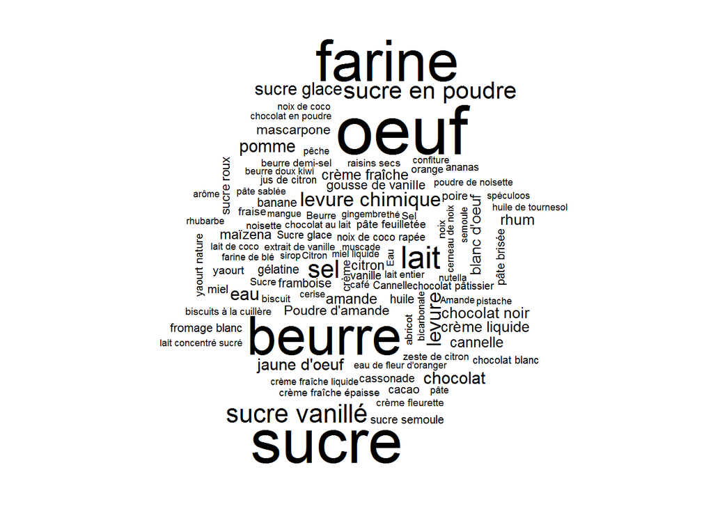

```r
top_100_ingredients <- top_n(freq_ingredients,100,freq)
wordcloud(words=top_100_ingredients$ingredients,
          freq= top_100_ingredients$freq)
```

### Commentaires

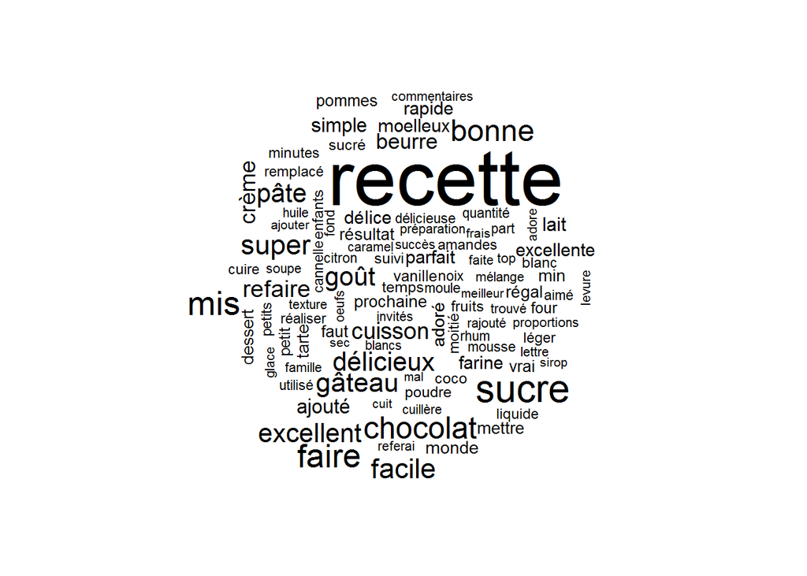

```r
top_100_mots=top_n(freq_mots,100,freq)
wordcloud(words=top_100_mots$word,
          freq=top_100_mots$freq)
```

## Barplots

Si on veut être en mesure de lire plus directement les fréquences d’occurrence des mots, alors on peut opter pour un graphique plus classique. Par la grâce de ggplot2! hop! un barplot!

### Ingrédients

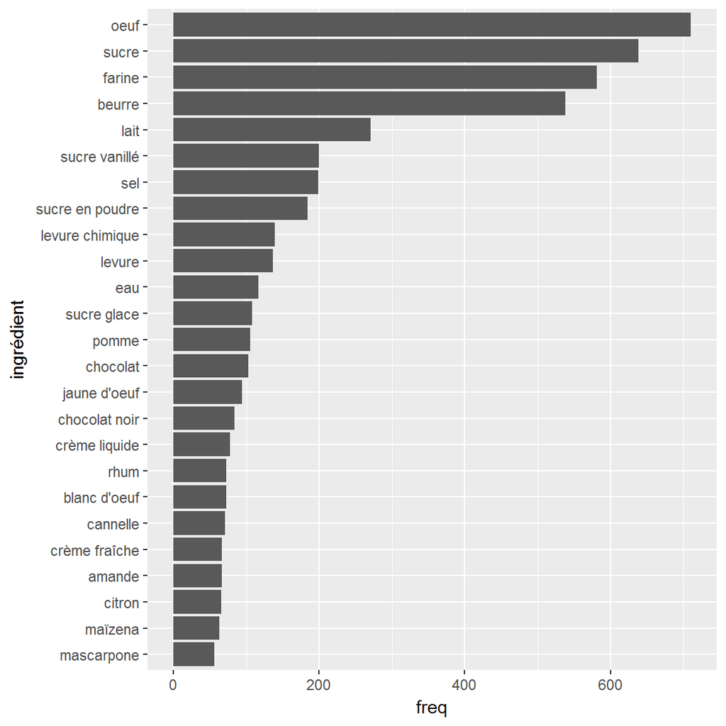

```r
top_25_ingredients=top_n(freq_ingredients,25, freq)
ggplot(top_25_ingredients, aes(x=forcats::fct_reorder(ingredients,freq), y=freq))+
  geom_bar(stat="identity")+
  coord_flip()+
  xlab("ingrédient")
```

### Commentaires

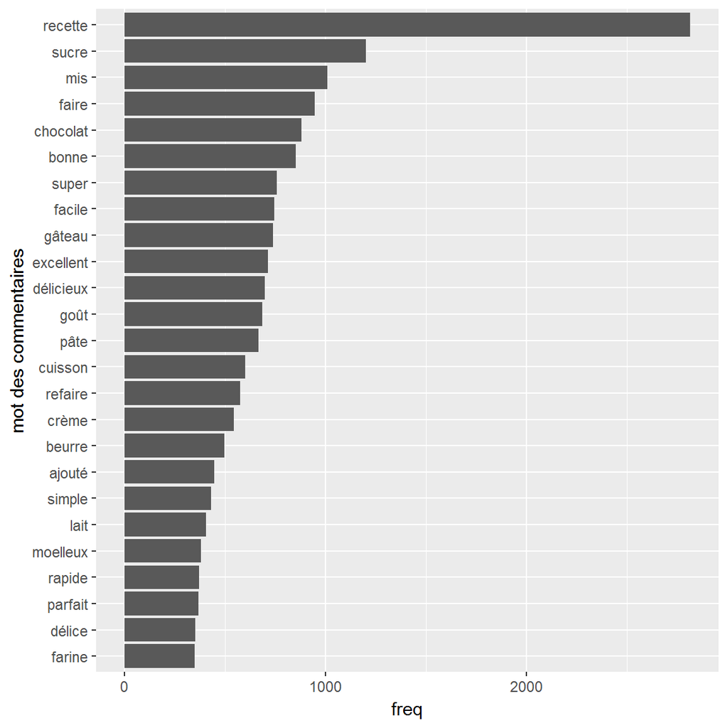

```r
top_25_mots=top_n(freq_mots, 25, freq)
ggplot(top_25_mots, aes(x=forcats::fct_reorder(word,freq), y=freq))+
  geom_bar(stat="identity")+
  coord_flip()+
  xlab("mot des commentaires")
```

# Co-occurences

On va maintenant s’intéresser aux co-occurrences de mots. Par exemple, intéressons-nous à la façon dont deux mots tendent à apparaître dans un même commentaire.

La librairie `widyr` permet d’obtenir les fréquences de co-occurrence et les corrélations deux à deux…

```r
tib_mots_filtree=tib_mots_nonvides %>%
  group_by(lemme) %>%
  mutate(n=n()) %>%
  filter(n>50) %>%
  ungroup()

mots_comptes=tib_mots_filtree %>%
  pairwise_count(lemme,recette,sort=TRUE)

mots_cors= tib_mots_filtree %>%
  pairwise_cor(lemme,recette,sort=TRUE)

mots_paires=left_join(mots_comptes,
                      mots_cors,
                      by=c("item1","item2"))
write_csv(mots_paires,"data/mots_paires.csv")
```

## Graphe représentant corrélations entre mots

On filtre les données `tib_mots_paires` pour écarter les paires qui ont soit une faible co-occurrence, soit une faible corrélation. Cela va nous permettre de construire un graphe plus lisible…

En effet, l’ensemble des paires listées dans le tableau `tib_graph` est pris en compte pour construire le layout du graphe… Pour le coup j’ai préféré utiliser les lemmes pour éviter de me retrouver avec des liens entre “bananes” et “banane”, “ajouté” et “ajouter”, etc.

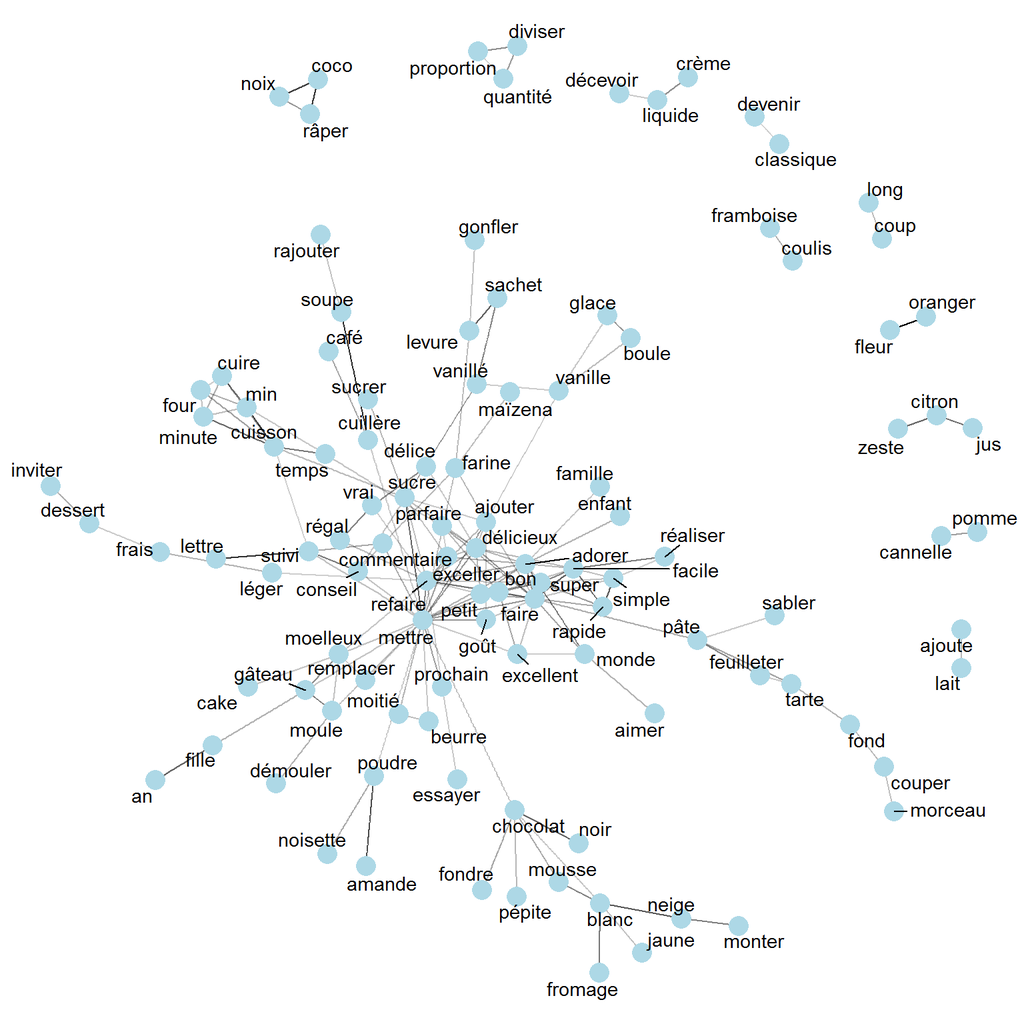

```r
tib_graph=mots_paires %>%
   filter(n>20,
          correlation>0.3,
          item1!="recette",
          item2!="recette") %>%
   select(-n)

graph_from_data_frame(tib_graph) %>%
   ggraph(layout = "fr") +
   geom_edge_link(aes(edge_alpha = correlation),
                  show.legend = FALSE) +
   geom_node_point(color = "lightblue", size = 5) +
   geom_node_text(aes(label = name), repel = TRUE) +
   theme_void()
```